# Week 4 Homework

Author

Anna Hiltner Nouzeilles

## Two Variables, Ten Categories

For this week’s homework, I will analyze two variables in the 2022 GSS with at least 10 categories.

1. TVHOURS
2. SIBS

## Hours Watching TV

The 2022 General Social Survey asks the following question: *“On the average day, about how many hours do you personally watch television?”*

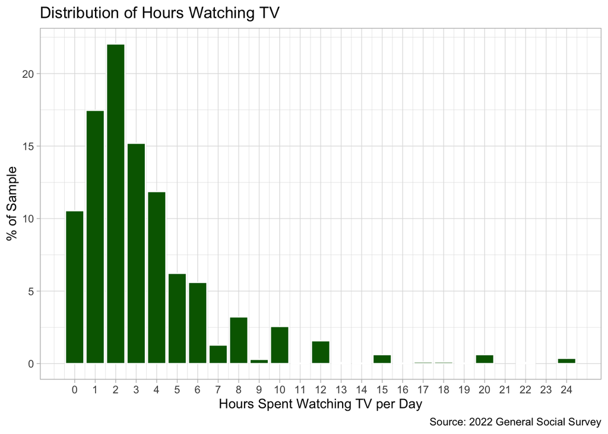

# Mean of tvhours

The mean of a sample is represented by this formula:
$$\bar{x} = \frac{1}{n} \sum_{i=1}^{n} x_i$$
The mean of tvhours is $\bar{x}$ = **3.4**. This means that, on average, individuals in this sample watched 3.4 hours of TV per day.

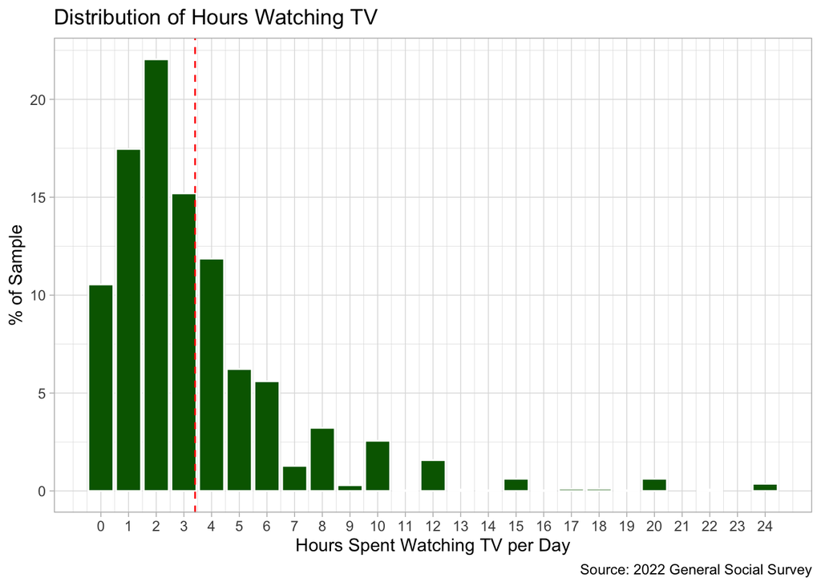

# Standard deviation of tvhours

The standard deviation of tvhours is **3.4**

This means a deviation from the mean of about 3.4 or less would not be unusual. The standard deviation is close to the mean, which means that the distribution has a lot of spread relative to the mean (from people reporting much higher values)

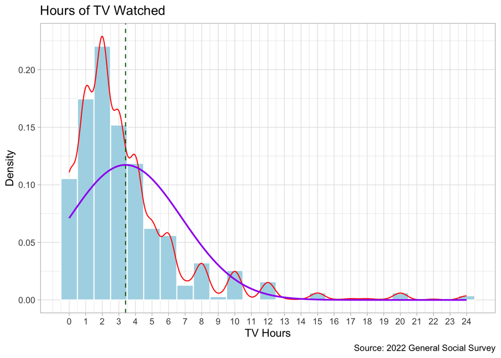

# Quality of the Normal Approximation

We can examine the center and spread to determine the quality of the normal approximation (purple curve) to the observed empirical distribution (histogram and red line). The histogram and density plot peak around 2-3 hours while the normal approximation peaks around 3-4 hours which means the normal approximation does not capture the true center of the data. The normal approximation covers the full range of values, but does not capture the small peaks or the extent of the right-skew of the empirical distribution. Because it is overestimating symmetry, the normal curve assumes a spread into the negative range which is not possible.

## Siblings

The 2022 General Social Survey asks the following question: *“How many brothers and sisters did you have?”*

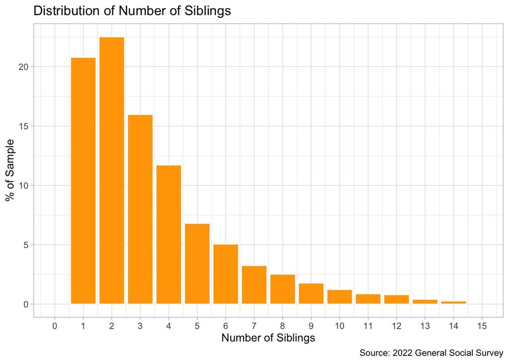

# Mean of sibs

$\bar{x}$ = **3.41**

This means that, on average, individuals in this sample had *3.41* siblings.

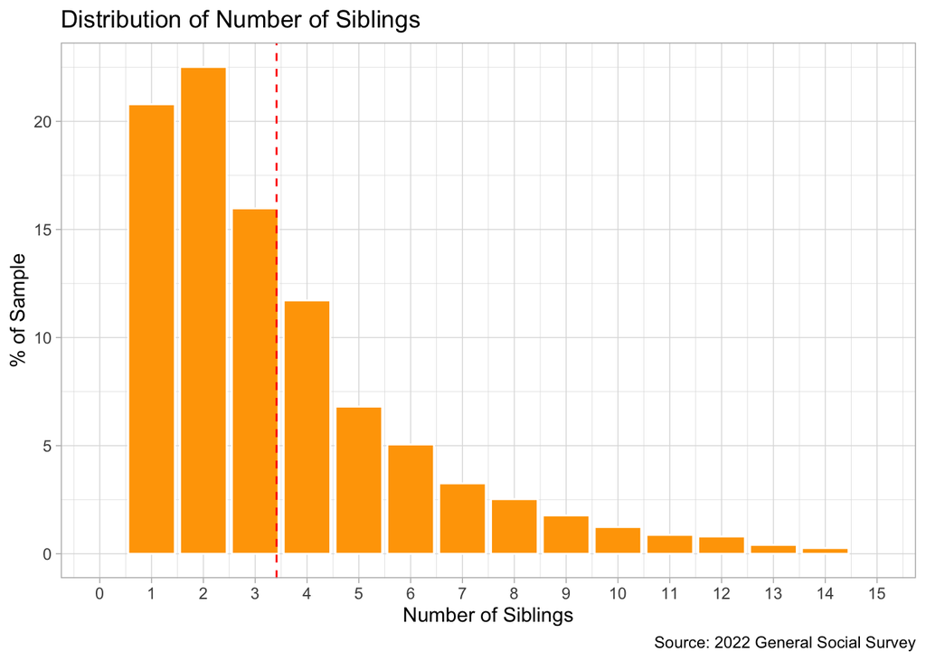

# Standard deviation of sibs

The standard deviation of sibs is **3**

This means a deviation from the mean of about 3 or less would not be unusual. The standard deviation is about the same as the mean, which means that there is a lot of spread in the distribution relative to the mean (from people reporting much higher values).

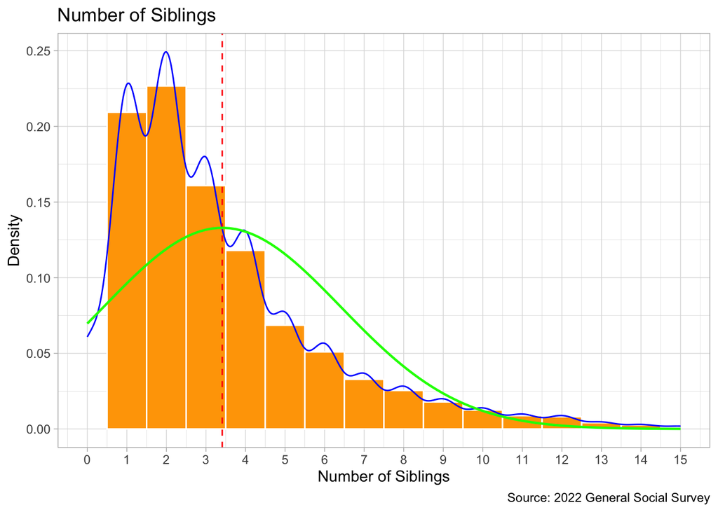

# Quality of the Normal Approximation

The normal approximation (green line) covers the overall spread of the data from 0-15. The center of the distribution is correct because it peaks at the mean of 3 siblings and the curve reflects the declining trend as the number of siblings increases. However, it fails to reflect the right-skew of the empirical distribution, overestimates higher sibling counts (4-8 siblings) and underestimates lower sibling counts (1-3 siblings). While the normal distribution reflects the mean and spread well, it fails to capture the true shape of the empirical distribution.